# Mon document

Moi

7 mars 2024

## Science des données

### TP n°1. Méthodes de classification

### Exercice 1. CAH d’un petit jeu de données

De nombreuses méthodes de classiffication sont proposées par exemple dans les packages `ade4`, `cluster` ou encore `FactoMineR`. Nous utiliserons pour ce TP le seul package `cluster` qui permet d’implémenter les algorithmes de classification les plus célèbres (CAH et k−means.) Par ailleurs, les résultats de la classification peuvent être représentés joliment grâce au package `factoextra`.

1. Installation puis chargement des packages :

```r
#install.packages("cluster", dependencies = TRUE)
#install.packages("factoextra", dependencies = TRUE)
library(cluster)
library(factoextra)
```

2. Créer le jeu de données des cinq individus décrits par deux variables x et y (exemple du cours).

```r
data5 <- data.frame(x=c(1,2,2,4,4), y=c(2,0.5,1,3,2))
```

3. Représenter ces données à l’aide d’un nuage de points :

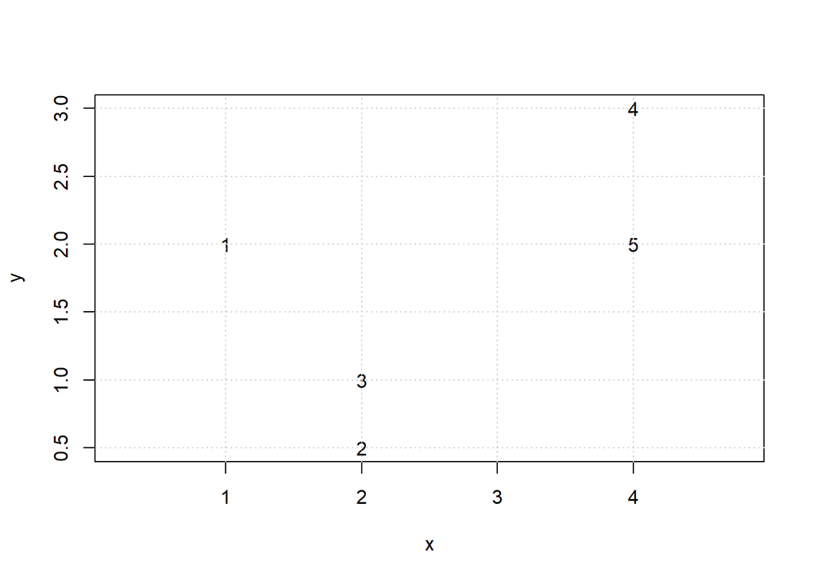

```r
plot(data5$x,data5$y, pch="", asp=1, xlab="x", ylab="y")
text(data5$x,data5$y,labels=row.names(data5))
grid(col="lightgrey", lty="dotted")
```

4. Procéder de même à l’aide du package `ggplot` :

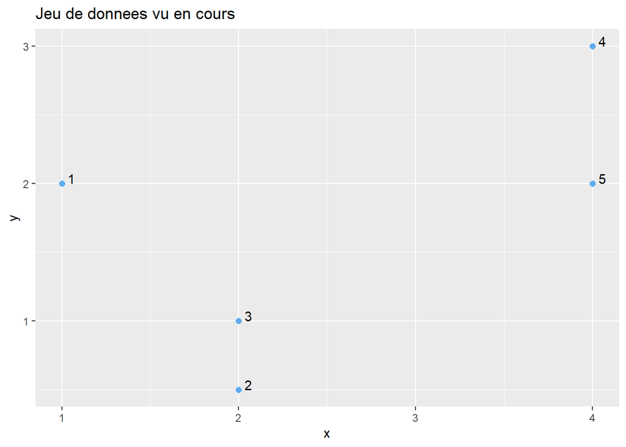

```r
library(ggplot2)
ggplot(data5, aes(x,y, label=rownames(data5))) +
geom_point(col = "steelblue2", size = 2) +
geom_text(hjust=-0.8, vjust=0) +
ggtitle("Jeu de donnees vu en cours")
```

Un peu plus esthétique en ajoutant la librairie ggrepel pour gérer l’apparence et le placement automatique des libellés :

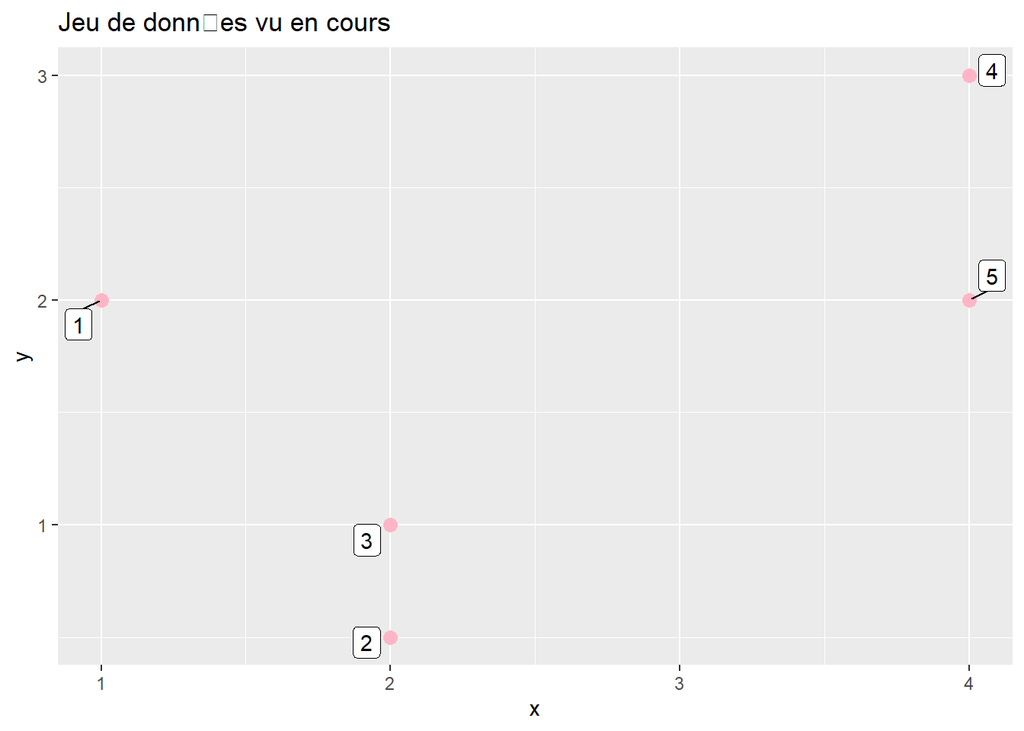

```r
library(ggrepel)
ggplot(data5, aes(x,y)) +
  geom_point(color = "pink1", size = 3) +
  geom_label_repel(aes(label = rownames(data5))) +
  ggtitle("Jeu de donn�es vu en cours")
```

5. À l’aide de la fonction `agnes` du package `cluster`, réaliser la CAH de ces individus avec les choix suivants : distance entre individus = `city-block` ; indice d’agrégation = lien minimum.

```r
# lien minimum
res.agnes <- agnes(data5, stand=F, metric="manhattan", method="single")
# lien maximum
res.agnes <- agnes(data5, stand=F, metric="manhattan", method="complete")

# Consulter l'objet r�sultat
res.agnes
```

```
## Call:     agnes(x = data5, metric = "manhattan", stand = F, method = "complete")
## Agglomerative coefficient:  0.7555556
## Order of objects:
## [1] 1 2 3 4 5
## Height (summary):
##    Min. 1st Qu.  Median    Mean 3rd Qu.    Max.
##   0.500   0.875   1.750   2.125   3.000   4.500
##
## Available components:
## [1] "order"  "height" "ac"     "merge"  "diss"   "call"   "method" "data"
```

Consulter le contenu de l’objet résultat.

6. Afficher les éléments `order`, `height` et merge de l’objet `res.agnes`.

```r
res.agnes$order # Ordre des éléments de gauche à droite sur l'axe horizontal
```

```
## [1] 1 2 3 4 5
```

```r
res.agnes$merge # Éléments (individus ou groupes) successivement agrégés
```

```
##      [,1] [,2]
## [1,]   -2   -3
## [2,]   -4   -5
## [3,]   -1    1
## [4,]    3    2
```

```r
res.agnes$height # Hauteur d'agrégation entre deux individus consécutifs
```

```
## [1] 2.5 0.5 4.5 1.0
```

À l’aide de ces éléments, reproduire le dendrogramme associé à la CAH.

7. Vérifier que l’arbre obtenu est conforme à la représentation obtenue par la commande ci-dessous. Deux graphiques sont successivement produits : un graphique en bannière puis le dendrogramme.

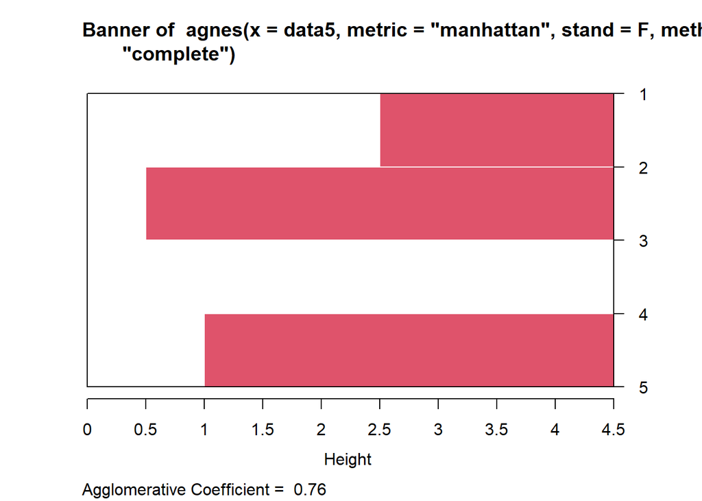

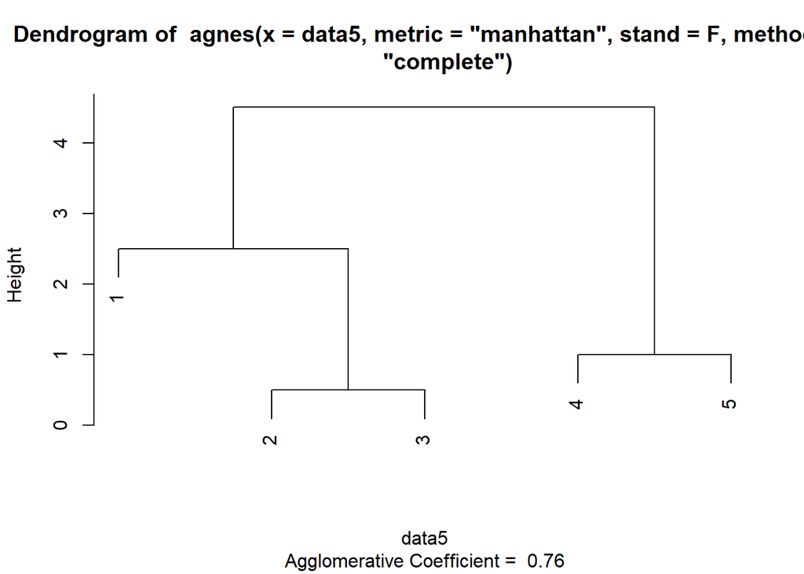

```r
plot(res.agnes)
```

8. Afficher maintenant le graphique en bannière. Comment celui-ci est-il obtenu ?

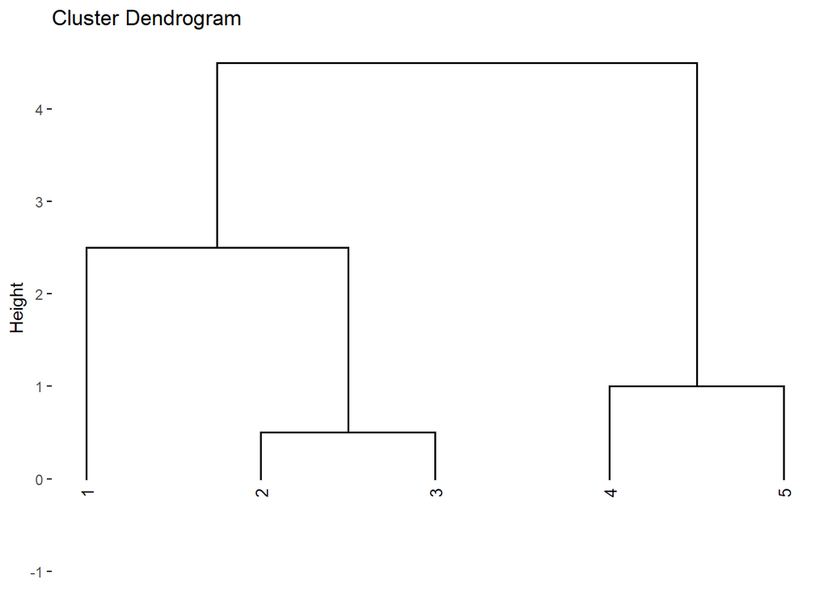

```r
fviz_dend(
 res.agnes,
 cex = 0.7,
 palette = "jco",
 rect = TRUE,
 rect_fill = TRUE,
 rect_border = "jco",
 labels_track_height = 0.8)
```

9. Repérer la valeur du coefficient AC (Agglomerative coefficient) associé au dendrogramme. Quelle est sa définition (consulter l’aide : `?agnes.object`) ? Comment interpréter graphiquement la valeur du coefficient `AC`?